# Modeling and Uncertainty

# Part 3: Case Studies

## Case Study: Longitudinal Cytokines

**Biological Question**

> Does treatment with the anti-inflammatory drug change cytokine concentrations post-treatment (week 1), and if so does the effect persist into the long-run (week 7)?

## Plot the data

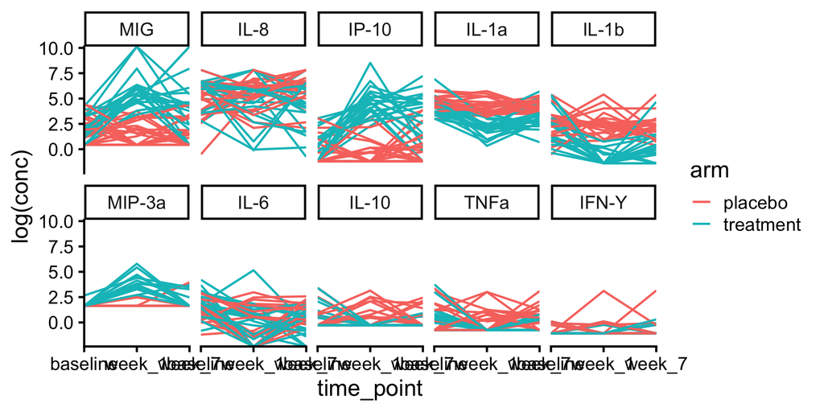

Roughly, a strong treatment effect one week post-intervention that weakens by week 7. We’ll focus on **IL-1a** — the cytokine with the fewest measurements below detection.

## Working assumptions

- Luminex gives a **continuous** readout → linear regression
- Many small, unrelated factors perturb the measurement → **Gaussian error**
- Errors are likely multiplicative, not additive → model **log-concentration**

## A first model

```r
cytokines_il1 <- cytokines |> filter(cytokine == "IL-1a")
fit <- lm(log(conc) ~ arm, data = cytokines_il1)
modelsummary(fit, shape = term ~ statistic, gof_map = NA)
```

|  | (1) Est. | (1) S.E. |
| --- | --- | --- |
| (Intercept) | 4.400 | 0.128 |
| armtreatment | -1.241 | 0.185 |

The treatment effect is significant — but **interpret a model only after checking its fidelity**.

## Check by simulation

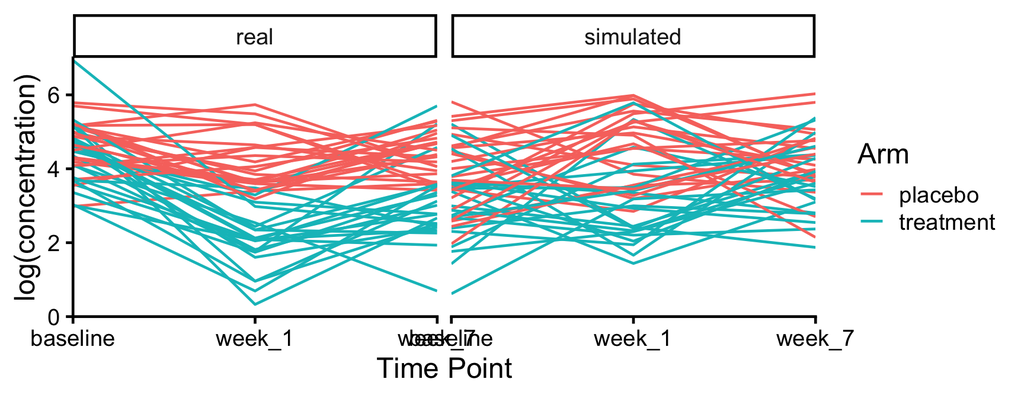

```r
sim_data <- simulate_cytokine(fit)
plot_cytokine(sim_data)
```

## What went wrong?

- ✅ Overall concentrations are in the correct range
- ✅ Control group has larger concentrations than treatment
- ❌ In the real data, **most blue curves decrease at week 1**
- ❌ In the simulation, about **half the curves increase**

## Revising the model

We gave the model **no temporal information**. One fix: `~ arm + time_point`.

But the data story isn’t quite right either — we don’t expect IL-1a concentration to change just because the clock reads week 1 or 7.

We want the **treatment effect itself to depend on the week**. That’s an interaction:

```r
log(conc) ~ arm + arm : time_point
```

## Fitted interaction model

```r
fit <- lm(log(conc) ~ arm + arm : time_point, data = cytokines_il1)
modelsummary(fit, shape = term ~ statistic, gof_map = NA)
```

|  | (1) Est. | (1) S.E. |
| --- | --- | --- |
| (Intercept) | 4.664 | 0.172 |
| armtreatment | -0.285 | 0.249 |
| armplacebo × time_pointweek_1 | -0.478 | 0.243 |
| armtreatment × time_pointweek_1 | -2.340 | 0.254 |
| armplacebo × time_pointweek_7 | -0.312 | 0.243 |
| armtreatment × time_pointweek_7 | -1.317 | 0.254 |

## Interpreting the coefficients

Expected log-concentrations:

- Placebo at baseline: **4.66**
- Treatment at baseline: 4.66 − 0.29
- Placebo at week 1: 4.66 − 0.48
- Treatment at week 1: 4.66 − 2.34
- …

The large negative coefficient for `armtreatment:time_pointweek_1` captures our earlier observation: **the treatment effect is strongest at week 1.**

## Exercise

🤔 Does this model allow for a treatment effect at time zero?

Based on what you know about the **large world** experiment, decide whether this is appropriate or if the model could be further improved.

## Re-check by simulation

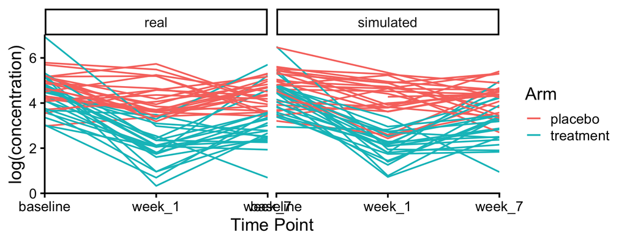

Much better.

## One more revision

The model treats each sample as independent, but **measurements from the same participant are dependent**.

The effective sample size lies somewhere between the number of **participants (44)** and **measurements (132)**.

→ Add a **participant-level random effect**.

## Mixed-effects fit

```r
fit <- lmer(log(conc) ~ arm + arm : time_point + (1 | pid), data = cytokines_il1)
modelsummary(fit, shape = term ~ statistic, gof_map = NA)
```

|  | (1) Est. | (1) S.E. |
| --- | --- | --- |
| (Intercept) | 4.664 | 0.172 |
| armtreatment | -0.285 | 0.249 |
| armplacebo × time_pointweek_1 | -0.478 | 0.239 |
| armtreatment × time_pointweek_1 | -2.340 | 0.250 |
| armplacebo × time_pointweek_7 | -0.312 | 0.239 |
| armtreatment × time_pointweek_7 | -1.317 | 0.250 |
| SD (Intercept pid) | 0.148 |  |
| SD (Observations) | 0.810 |  |

## Why bother?

- Visually, the model doesn’t seem much better.
- Participant variation (SD **0.15**) is small vs. within-sample (**0.81**).
- But it’s the **safer model** in practice — by accounting for within-participant dependence, we’re being honest about the effective sample size.

## Final simulation check

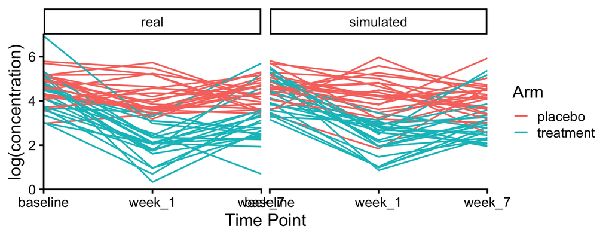

# Wrapping Up

## What we did today

1. Models as **data stories** — small world vs. large world.
2. A **modeling checklist** to guide our work: question → plot → assumptions → checks → revise.
3. A tour through the **model zoo**: bernoulli, binomial, Poisson, negative binomial, linear, survival.
4. **Variations** for richer data: multiple predictors, mixed effects, interactions.
5. Two **case studies** showing the checklist in action.

## The key habit

> Fit. **Simulate.** Compare to real data. Revise.

A model that hasn’t been checked against the data it claims to describe is not yet trustworthy — even if its p-values look exciting.

## Questions?

🐘 Welcome to the model zoo

# Bonus Material

## Case Study 2: Flow Cytometry Cell Compositions

> Does the inflammation-reducing drug influence **immune cell composition at week 1** post-treatment?

## Load the data

Since the question focuses on `week_1`, we keep only those sample IDs.

```r
ids_w1 <- read_csv(here("datasets/instructional_dataset/00_sample_ids_UKZN_workshop_2023.csv")) |>
    filter(time_point == "week_1")
flow <- read_csv(here("datasets/instructional_dataset/04_flow_cytometry_UKZN_workshop_2023.csv")) |>
    right_join(ids_w1) |>
    mutate(arm = as.factor(arm))
head(flow)
```

```
## # A tibble: 6 × 13
##   sample_id live_cd19_negative cd45_negative cd45_positive neutrophils
##   <chr>                  <dbl>         <dbl>         <dbl>       <dbl>
## 1 SAMP052               347091        259075         86122       53132
## 2 SAMP025               115716         27779         83689       56681
## 3 SAMP040               576299        538725         36244       23491
## 4 SAMP101               526335        445947         78615       51813
## 5 SAMP096               239933        187379         49636       41053
## 6 SAMP087               110029         73529         35053       29168
## # ℹ 8 more variables: non_neutrophils <dbl>, cd3_negative <dbl>,
## #   cd3_positive <dbl>, cd4_t_cells <dbl>, cd8_t_cells <dbl>, pid <chr>,
## #   time_point <chr>, arm <fct>
```

## Plot the data

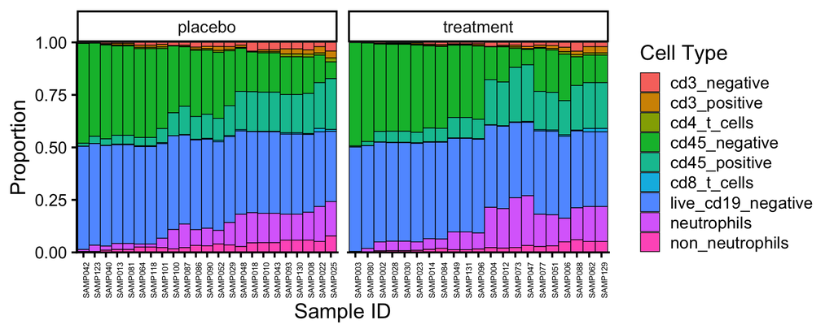

Samples sorted so that those with lower cell-type diversity appear on the left.

## What are we asking?

Is there a **systematic difference in cell compositions** between treatment and control at week 1?

If so, **which cell types** are responsible?

## The large-world data story

- ~1 **trillion** immune cells circulating through a typical body. Some types far rarer than others. Cells created and destroyed all the time, not evenly distributed.
- At the doctor’s office a **CVL is collected**, catching some of those cells at the right place and time. A technician freezes the sample, killing all cells.
- Later, sample is prepared for the **flow cytometer**. Most (but not all) cell-surface markers are bound by labeled antibodies. All cells are destroyed.
- A computational biologist **gates** the raw output into cell types. Unrecognized ones are dropped. The data are saved to a CSV.

This is a **big world** — our final file is an imperfect view. Sampling variation and measurement error enter at every step.

## Working assumptions

Consider the population of immune cells in one participant. When we draw a sample, we “catch” a mix of CD3- and other cell types.

With only **two groups** (CD3- and “other”) and only **totals observed** per participant, this is a natural setting for a **binomial** model.

## First binomial fit

```r
flow <- flow |>
    mutate(
        total = rowSums(across(2:10)),
        proportion = cd3_negative / total
    )

fit <- glm(proportion ~ 1, family = binomial(), weights = total, data = flow)
modelsummary(fit, shape = term ~ statistic, gof_map = NA)
```

|  | (1) Est. | (1) S.E. |
| --- | --- | --- |
| (Intercept) | -4.263 | 0.001 |

## What does that estimate mean?

After the inverse logistic transformation, the estimate is just the **fraction of observed cells assigned to CD3-**:

```r
plogis(-4.26)
```

```
## [1] 0.01392564
```

```r
sum(flow$cd3_negative) / sum(flow$total)
```

```
## [1] 0.01388184
```

## Checking by simulation

```r
y_sim <- simulate(fit)$sim_1
head(y_sim)
```

```
## [1] 0.01376613 0.01389475 0.01397713 0.01378645 0.01403202 0.01416343
```

The fitted CD3- proportions are **close to but not exactly** those in the real data — reflecting the randomness of the binomial model.

## Looping over cell types

`fit_cytof` loops this model over **all** cell types and simulates new counts.

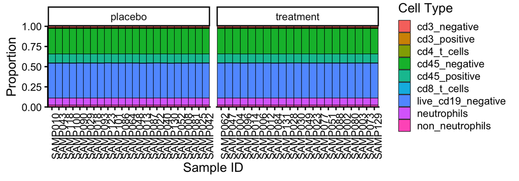

```r
m <- fit_cytof(proportion ~ 1)
counts <- simulate_counts(m)
plot_counts(counts)
```

## Two issues stand out

1. The fitted proportions are **very close** to the estimated proportions across all samples — the binomial has **much lower variability** than the real data.
2. Our model doesn’t let cell-type proportions **vary across treatment and control**.

We’ll fix the second issue first — it’s easier.

## Add treatment to the model

Modify the formula from `proportion ~ 1` to `proportion ~ arm`.

```r
m <- fit_cytof(proportion ~ arm)
coef_df <- map_dfr(m, coef, .id = "cell_type")
coef_df
```

```
## # A tibble: 9 × 3
##   cell_type          `(Intercept)` armtreatment
##   <chr>                      <dbl>        <dbl>
## 1 live_cd19_negative        -0.283      0.0207
## 2 cd45_negative             -0.773     -0.00320
## 3 cd45_positive             -2.11       0.0531
## 4 neutrophils               -2.48       0.221
## 5 non_neutrophils           -3.45      -0.513
## 6 cd3_negative              -3.98      -0.578
## 7 cd3_positive              -4.54      -0.444
## 8 cd4_t_cells               -5.18      -0.482
## 9 cd8_t_cells               -5.66      -0.338
```

## Interpreting the treatment effect

For `cd3_negative`:

- Placebo: `plogis(-3.98) ≈ 0.018`
- Treatment: `plogis(-3.98 − 0.578) ≈ 0.010`

But **we shouldn’t trust this model yet** — it still fails to account for sample-to-sample variability.

## Still too tight

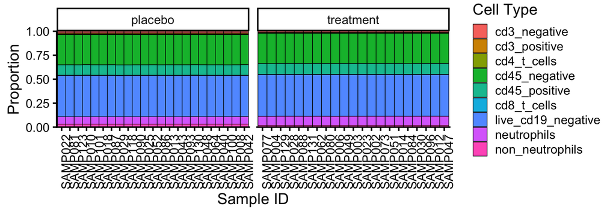

## Add a sample random effect

Add `(1 | sample_id)` and switch from `glm` to `glmer`:

```
proportion ~ arm + (1 | sample_id)
```

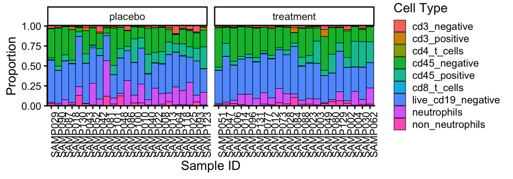

```r
fits <- fit_cytof(proportion ~ arm + (1 | sample_id), glmer)
counts <- simulate_counts(fits)
plot_counts(counts)
```

## A realistic-looking model

- Much more realistic simulations 🎉
- Still no smooth variation across samples — could add latent factors / correlations across cell types
- But this is often **sufficient for real data analyses**, and underlies the `diffcyt` Bioconductor package

## Model output

```r
modelsummary(fits[["cd3_negative"]], shape = term ~ statistic, gof_map = NA)
```

|  | (1) Est. | (1) S.E. |
| --- | --- | --- |
| (Intercept) | -4.229 | 0.220 |
| armtreatment | -0.611 | 0.319 |
| SD (Intercept sample_id) | 1.057 |  |

- `armtreatment` — how treatment shifts this cell-type proportion
- `sample_id Std. Dev.` — how much varies across samples

## Exercise

🤔 According to the fitted model, what is the **typical proportion of CD3- cells** in the control and treatment groups?

*Hint:* Use the `plogis` function applied to the right choice of values under `Estimate`.